# K-NEAREST NEIGHBOURS

##### Objective:

The objective of this assignment is to implement and evaluate the K-Nearest Neighbours algorithm for classification using the given datasets

### Import necessary libraries

```python
import pandas as pd
import numpy as np
import seaborn as sns
import matplotlib.pyplot as plt
from sklearn.model_selection import train_test_split
from sklearn.metrics import confusion_matrix,classification_report,accuracy_score
from sklearn.neighbors import KNeighborsClassifier
```

## Sept1 :- Data exploration

```python
zoo = pd.read_csv("/Users/jagdishreddy/Downloads/KNN/Zoo.csv")
```

```python
zoo.head()
```

|  | animal name | hair | feathers | eggs | milk | airborne | aquatic | predator | toothed | backbone | breathes | venomous | fins | legs | tail | domestic | catsize | type |
| --- | --- | --- | --- | --- | --- | --- | --- | --- | --- | --- | --- | --- | --- | --- | --- | --- | --- | --- |
| 0 | aardvark | 1 | 0 | 0 | 1 | 0 | 0 | 1 | 1 | 1 | 1 | 0 | 0 | 4 | 0 | 0 | 1 | 1 |
| 1 | antelope | 1 | 0 | 0 | 1 | 0 | 0 | 0 | 1 | 1 | 1 | 0 | 0 | 4 | 1 | 0 | 1 | 1 |
| 2 | bass | 0 | 0 | 1 | 0 | 0 | 1 | 1 | 1 | 1 | 0 | 0 | 1 | 0 | 1 | 0 | 0 | 4 |
| 3 | bear | 1 | 0 | 0 | 1 | 0 | 0 | 1 | 1 | 1 | 1 | 0 | 0 | 4 | 0 | 0 | 1 | 1 |
| 4 | boar | 1 | 0 | 0 | 1 | 0 | 0 | 1 | 1 | 1 | 1 | 0 | 0 | 4 | 1 | 0 | 1 | 1 |

```python
zoo.shape
```

```
(101, 18)
```

```python
zoo.size
```

```
1818
```

```python
zoo.duplicated()
```

```
0      False
1      False
2      False
3      False
4      False
       ...
96     False
97     False
98     False
99     False
100    False
Length: 101, dtype: bool
```

```python
zoo.info()
```

```
<class 'pandas.core.frame.DataFrame'>
RangeIndex: 101 entries, 0 to 100
Data columns (total 18 columns):
 #   Column       Non-Null Count  Dtype
---  ------       --------------  -----
 0   animal name  101 non-null    object
 1   hair         101 non-null    int64
 2   feathers     101 non-null    int64
 3   eggs         101 non-null    int64
 4   milk         101 non-null    int64
 5   airborne     101 non-null    int64
 6   aquatic      101 non-null    int64
 7   predator     101 non-null    int64
 8   toothed      101 non-null    int64
 9   backbone     101 non-null    int64
 10  breathes     101 non-null    int64
 11  venomous     101 non-null    int64
 12  fins         101 non-null    int64
 13  legs         101 non-null    int64
 14  tail         101 non-null    int64
 15  domestic     101 non-null    int64
 16  catsize      101 non-null    int64
 17  type         101 non-null    int64
dtypes: int64(17), object(1)
memory usage: 14.3+ KB
```

```python
zoo.isnull().sum()
```

```
animal name    0
hair           0
feathers       0
eggs           0
milk           0
airborne       0
aquatic        0
predator       0
toothed        0
backbone       0
breathes       0
venomous       0
fins           0
legs           0
tail           0
domestic       0
catsize        0
type           0
dtype: int64
```

```python
zoo['animal name'].value_counts
```

```
<bound method IndexOpsMixin.value_counts of 0      aardvark
1      antelope
2          bass
3          bear
4          boar
         ...
96      wallaby
97         wasp
98         wolf
99         worm
100        wren
Name: animal name, Length: 101, dtype: object>
```

```python
zoo['animal name'].unique()
```

```
array(['aardvark', 'antelope', 'bass', 'bear', 'boar', 'buffalo', 'calf',
       'carp', 'catfish', 'cavy', 'cheetah', 'chicken', 'chub', 'clam',
       'crab', 'crayfish', 'crow', 'deer', 'dogfish', 'dolphin', 'dove',
       'duck', 'elephant', 'flamingo', 'flea', 'frog', 'fruitbat',
       'giraffe', 'girl', 'gnat', 'goat', 'gorilla', 'gull', 'haddock',
       'hamster', 'hare', 'hawk', 'herring', 'honeybee', 'housefly',
       'kiwi', 'ladybird', 'lark', 'leopard', 'lion', 'lobster', 'lynx',
       'mink', 'mole', 'mongoose', 'moth', 'newt', 'octopus', 'opossum',
       'oryx', 'ostrich', 'parakeet', 'penguin', 'pheasant', 'pike',
       'piranha', 'pitviper', 'platypus', 'polecat', 'pony', 'porpoise',
       'puma', 'pussycat', 'raccoon', 'reindeer', 'rhea', 'scorpion',
       'seahorse', 'seal', 'sealion', 'seasnake', 'seawasp', 'skimmer',
       'skua', 'slowworm', 'slug', 'sole', 'sparrow', 'squirrel',
       'starfish', 'stingray', 'swan', 'termite', 'toad', 'tortoise',
       'tuatara', 'tuna', 'vampire', 'vole', 'vulture', 'wallaby', 'wasp',
       'wolf', 'worm', 'wren'], dtype=object)
```

```python
zoo['animal name'] = zoo['animal name'].astype('string')
```

```python
zoo.dtypes
```

```
animal name    string
hair            int64
feathers        int64
eggs            int64
milk            int64
airborne        int64
aquatic         int64
predator        int64
toothed         int64
backbone        int64
breathes        int64
venomous        int64
fins            int64
legs            int64
tail            int64
domestic        int64
catsize         int64
type            int64
dtype: object
```

```python
from sklearn.preprocessing import LabelEncoder

Le = LabelEncoder()
zoo['animal name'] = Le.fit_transform(zoo['animal name'])
```

```python
zoo
```

|  | animal name | hair | feathers | eggs | milk | airborne | aquatic | predator | toothed | backbone | breathes | venomous | fins | legs | tail | domestic | catsize | type |
| --- | --- | --- | --- | --- | --- | --- | --- | --- | --- | --- | --- | --- | --- | --- | --- | --- | --- | --- |
| 0 | 0 | 1 | 0 | 0 | 1 | 0 | 0 | 1 | 1 | 1 | 1 | 0 | 0 | 4 | 0 | 0 | 1 | 1 |
| 1 | 1 | 1 | 0 | 0 | 1 | 0 | 0 | 0 | 1 | 1 | 1 | 0 | 0 | 4 | 1 | 0 | 1 | 1 |
| 2 | 2 | 0 | 0 | 1 | 0 | 0 | 1 | 1 | 1 | 1 | 0 | 0 | 1 | 0 | 1 | 0 | 0 | 4 |
| 3 | 3 | 1 | 0 | 0 | 1 | 0 | 0 | 1 | 1 | 1 | 1 | 0 | 0 | 4 | 0 | 0 | 1 | 1 |
| 4 | 4 | 1 | 0 | 0 | 1 | 0 | 0 | 1 | 1 | 1 | 1 | 0 | 0 | 4 | 1 | 0 | 1 | 1 |
| ... | ... | ... | ... | ... | ... | ... | ... | ... | ... | ... | ... | ... | ... | ... | ... | ... | ... | ... |
| 96 | 95 | 1 | 0 | 0 | 1 | 0 | 0 | 0 | 1 | 1 | 1 | 0 | 0 | 2 | 1 | 0 | 1 | 1 |
| 97 | 96 | 1 | 0 | 1 | 0 | 1 | 0 | 0 | 0 | 0 | 1 | 1 | 0 | 6 | 0 | 0 | 0 | 6 |
| 98 | 97 | 1 | 0 | 0 | 1 | 0 | 0 | 1 | 1 | 1 | 1 | 0 | 0 | 4 | 1 | 0 | 1 | 1 |
| 99 | 98 | 0 | 0 | 1 | 0 | 0 | 0 | 0 | 0 | 0 | 1 | 0 | 0 | 0 | 0 | 0 | 0 | 7 |
| 100 | 99 | 0 | 1 | 1 | 0 | 1 | 0 | 0 | 0 | 1 | 1 | 0 | 0 | 2 | 1 | 0 | 0 | 2 |

101 rows × 18 columns

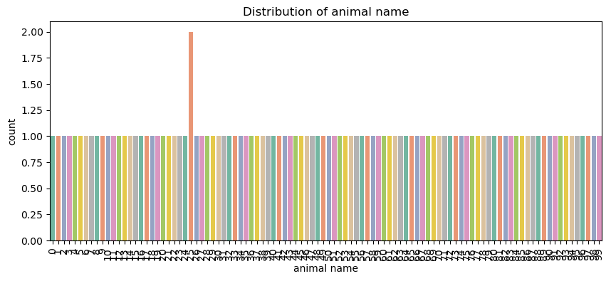

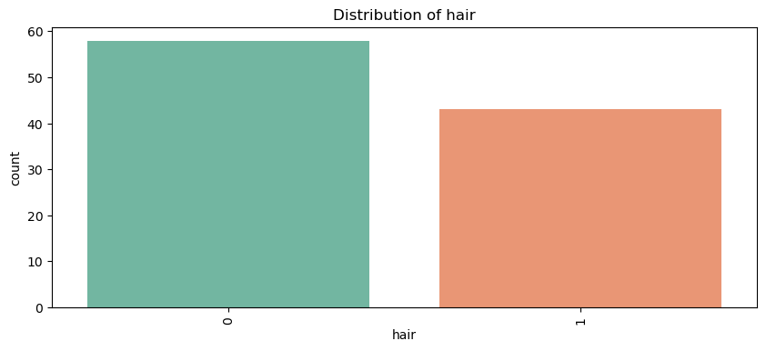

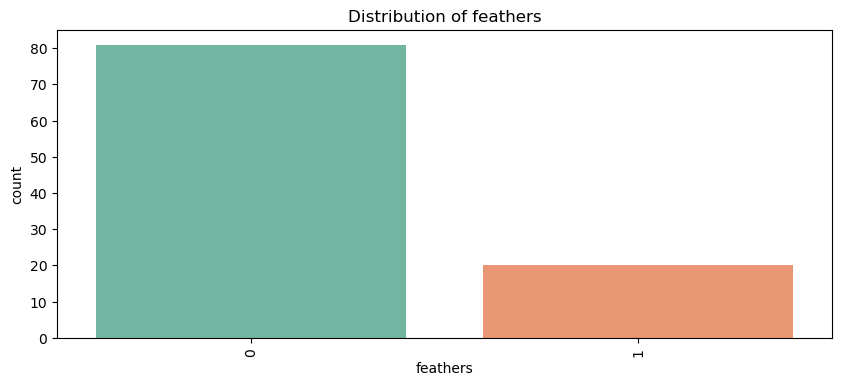

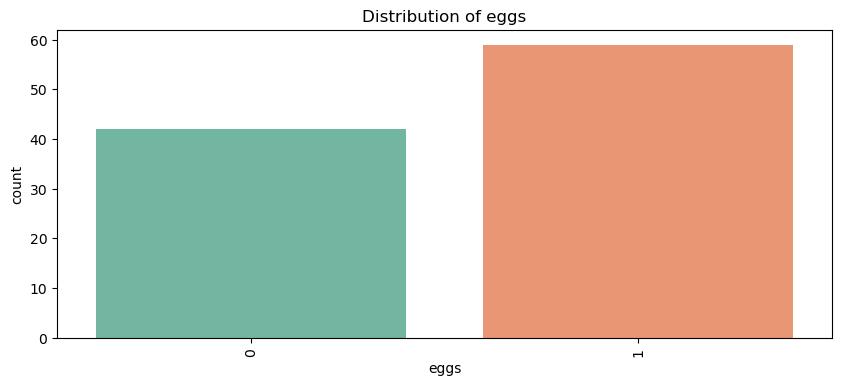

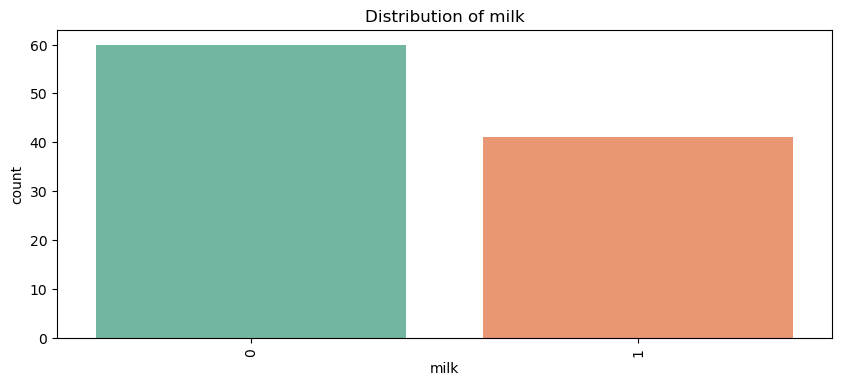

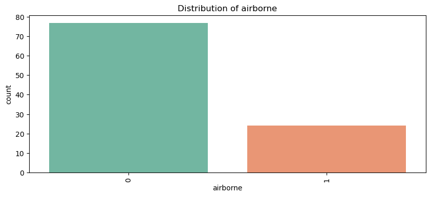

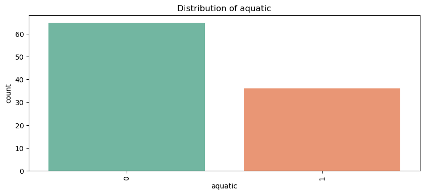

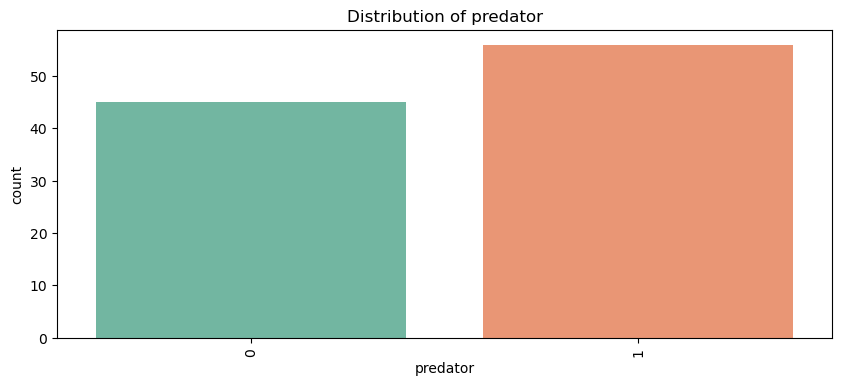

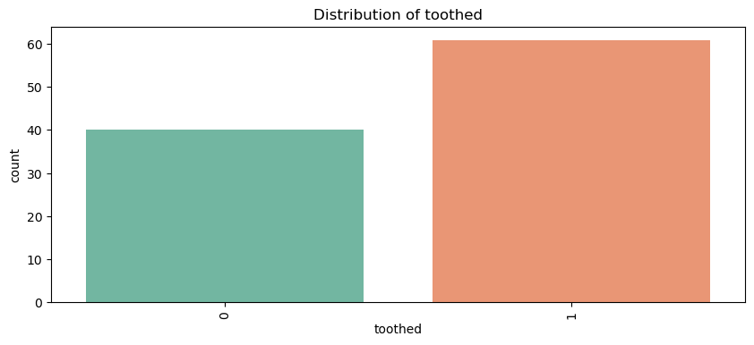

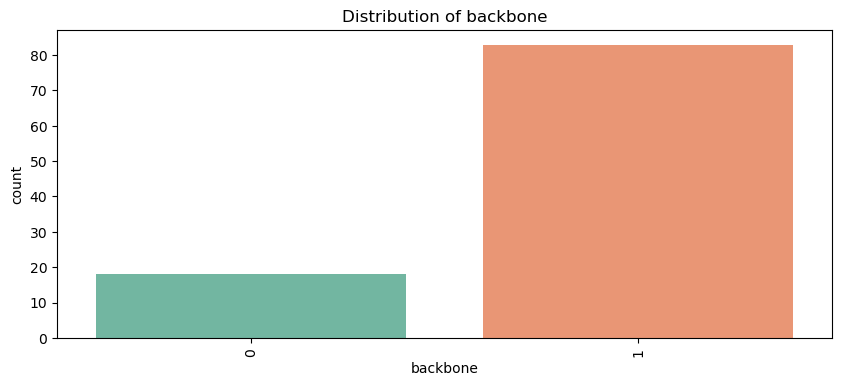

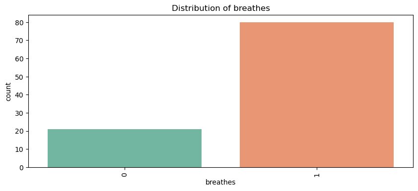

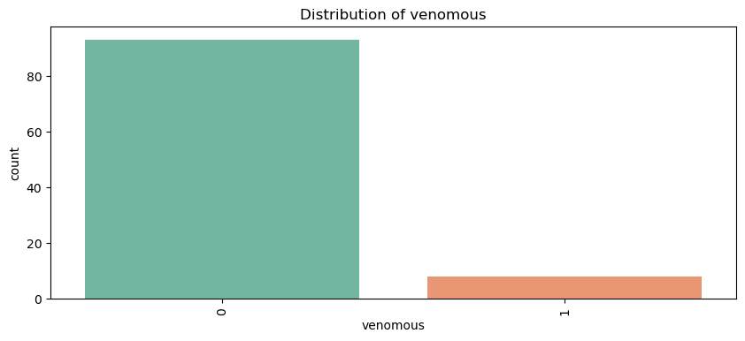

[6 more figures not shown]

```python
for column in zoo.columns:
    plt.figure(figsize=(10, 4))
    sns.countplot(x=column, data=zoo, palette='Set2')
    plt.title(f'Distribution of {column}')
    plt.xticks(rotation=90)
    plt.show()
```

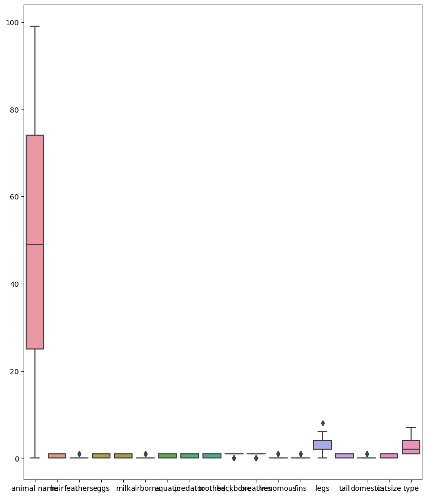

```python
plt.figure(figsize=(10,12))
sns.boxplot(data=zoo)
```

## Standardize the Variables

Because the KNN classifier predicts the class of a given test observation by identifying the observations that are nearest to it, the scale of the variables matters. Any variables that are on a large scale will have a much larger effect on the distance between the observations, and hence on the KNN classifier, than variables that are on a small scale.

```python
from sklearn.preprocessing import StandardScaler
```

```python
Standard_Scaler = StandardScaler()
```

```python
#Standard_Scaler.fit(zoo.drop('type',axis=1))
```

```python
#Scales_features = Standard_Scaler.transform(zoo.drop('type',axis=1))
```

```python
Scales_features = Standard_Scaler.fit_transform(zoo.drop('type',axis=1))
```

```python
Scales_features
```

```
array([[-1.70884021,  1.16139451, -0.49690399, ..., -1.69841555,
        -0.38435306,  1.13818037],
       [-1.67414817,  1.16139451, -0.49690399, ...,  0.58878406,
        -0.38435306,  1.13818037],
       [-1.63945614, -0.86103386, -0.49690399, ...,  0.58878406,
        -0.38435306, -0.87859537],
       ...,
       [ 1.65628693,  1.16139451, -0.49690399, ...,  0.58878406,
        -0.38435306,  1.13818037],
       [ 1.69097896, -0.86103386, -0.49690399, ..., -1.69841555,
        -0.38435306, -0.87859537],
       [ 1.725671  , -0.86103386,  2.01246118, ...,  0.58878406,
        -0.38435306, -0.87859537]])
```

```python
zoo_feat = pd.DataFrame(Scales_features,columns=zoo.columns[:-1])
```

```python
zoo_feat
```

|  | animal name | hair | feathers | eggs | milk | airborne | aquatic | predator | toothed | backbone | breathes | venomous | fins | legs | tail | domestic | catsize |
| --- | --- | --- | --- | --- | --- | --- | --- | --- | --- | --- | --- | --- | --- | --- | --- | --- | --- |
| 0 | -1.708840 | 1.161395 | -0.496904 | -1.185227 | 1.209717 | -0.558291 | -0.744208 | 0.896421 | 0.809776 | 0.46569 | 0.512348 | -0.293294 | -0.449868 | 0.572540 | -1.698416 | -0.384353 | 1.138180 |
| 1 | -1.674148 | 1.161395 | -0.496904 | -1.185227 | 1.209717 | -0.558291 | -0.744208 | -1.115547 | 0.809776 | 0.46569 | 0.512348 | -0.293294 | -0.449868 | 0.572540 | 0.588784 | -0.384353 | 1.138180 |
| 2 | -1.639456 | -0.861034 | -0.496904 | 0.843721 | -0.826640 | -0.558291 | 1.343710 | 0.896421 | 0.809776 | 0.46569 | -1.951800 | -0.293294 | 2.222876 | -1.404435 | 0.588784 | -0.384353 | -0.878595 |
| 3 | -1.604764 | 1.161395 | -0.496904 | -1.185227 | 1.209717 | -0.558291 | -0.744208 | 0.896421 | 0.809776 | 0.46569 | 0.512348 | -0.293294 | -0.449868 | 0.572540 | -1.698416 | -0.384353 | 1.138180 |
| 4 | -1.570072 | 1.161395 | -0.496904 | -1.185227 | 1.209717 | -0.558291 | -0.744208 | 0.896421 | 0.809776 | 0.46569 | 0.512348 | -0.293294 | -0.449868 | 0.572540 | 0.588784 | -0.384353 | 1.138180 |
| ... | ... | ... | ... | ... | ... | ... | ... | ... | ... | ... | ... | ... | ... | ... | ... | ... | ... |
| 96 | 1.586903 | 1.161395 | -0.496904 | -1.185227 | 1.209717 | -0.558291 | -0.744208 | -1.115547 | 0.809776 | 0.46569 | 0.512348 | -0.293294 | -0.449868 | -0.415948 | 0.588784 | -0.384353 | 1.138180 |
| 97 | 1.621595 | 1.161395 | -0.496904 | 0.843721 | -0.826640 | 1.791182 | -0.744208 | -1.115547 | -1.234909 | -2.14735 | 0.512348 | 3.409545 | -0.449868 | 1.561027 | -1.698416 | -0.384353 | -0.878595 |
| 98 | 1.656287 | 1.161395 | -0.496904 | -1.185227 | 1.209717 | -0.558291 | -0.744208 | 0.896421 | 0.809776 | 0.46569 | 0.512348 | -0.293294 | -0.449868 | 0.572540 | 0.588784 | -0.384353 | 1.138180 |
| 99 | 1.690979 | -0.861034 | -0.496904 | 0.843721 | -0.826640 | -0.558291 | -0.744208 | -1.115547 | -1.234909 | -2.14735 | 0.512348 | -0.293294 | -0.449868 | -1.404435 | -1.698416 | -0.384353 | -0.878595 |
| 100 | 1.725671 | -0.861034 | 2.012461 | 0.843721 | -0.826640 | 1.791182 | -0.744208 | -1.115547 | -1.234909 | 0.46569 | 0.512348 | -0.293294 | -0.449868 | -0.415948 | 0.588784 | -0.384353 | -0.878595 |

101 rows × 17 columns

## Pair Plot

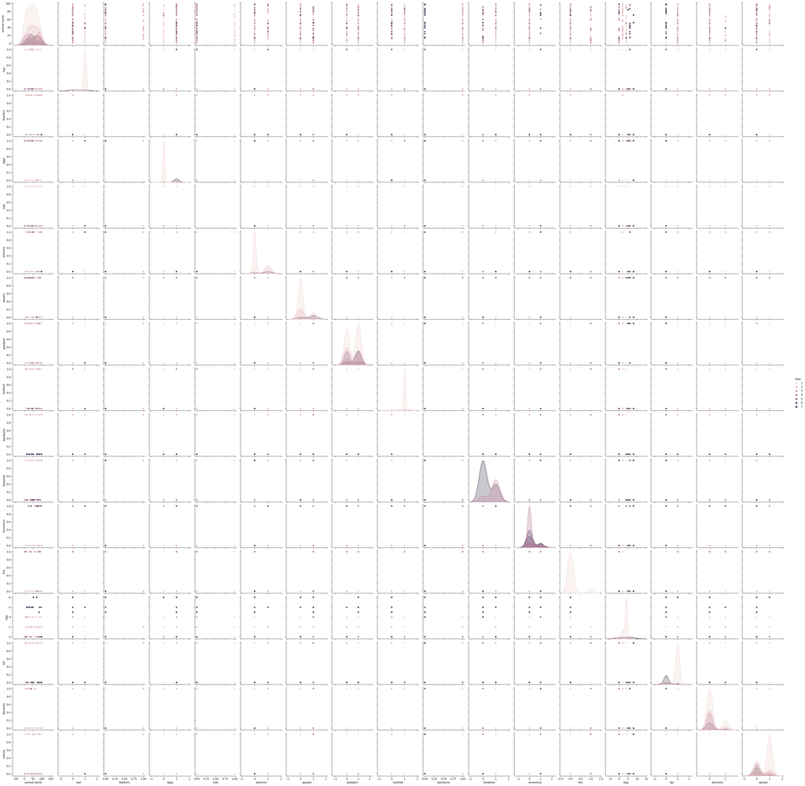

```python
sns.pairplot(data=zoo,hue='type')
```

## outliers detection using the IQR method

```python
Q1 = zoo['legs'].quantile(0.25)
Q3 = zoo['legs'].quantile(0.75)
```

```python
Q1,Q3
```

```
(2.0, 4.0)
```

```python
IQR = Q3-Q1
```

```python
IQR
```

```
2.0
```

```python
LQ = Q1-1.5*IQR
UQ = Q3+1.5*IQR
```

```python
LQ,UQ
```

```
(-1.0, 7.0)
```

```python
zoo_outliers_legs = zoo[(zoo['legs']<LQ)|(zoo['legs']>UQ)]
```

```python
zoo_outliers_legs
```

|  | animal name | hair | feathers | eggs | milk | airborne | aquatic | predator | toothed | backbone | breathes | venomous | fins | legs | tail | domestic | catsize | type |
| --- | --- | --- | --- | --- | --- | --- | --- | --- | --- | --- | --- | --- | --- | --- | --- | --- | --- | --- |
| 53 | 52 | 0 | 0 | 1 | 0 | 0 | 1 | 1 | 0 | 0 | 0 | 0 | 0 | 8 | 0 | 0 | 1 | 7 |
| 72 | 71 | 0 | 0 | 0 | 0 | 0 | 0 | 1 | 0 | 0 | 1 | 1 | 0 | 8 | 1 | 0 | 0 | 7 |

## Step2 :- Splitting the data

```python
X = zoo_feat.iloc[:,:-1]
y = zoo.iloc[:,-1]
```

```python
X,y
```

```
(     animal name      hair  feathers      eggs      milk  airborne   aquatic  \
 0      -1.708840  1.161395 -0.496904 -1.185227  1.209717 -0.558291 -0.744208
 1      -1.674148  1.161395 -0.496904 -1.185227  1.209717 -0.558291 -0.744208
 2      -1.639456 -0.861034 -0.496904  0.843721 -0.826640 -0.558291  1.343710
 3      -1.604764  1.161395 -0.496904 -1.185227  1.209717 -0.558291 -0.744208
 4      -1.570072  1.161395 -0.496904 -1.185227  1.209717 -0.558291 -0.744208
 ..           ...       ...       ...       ...       ...       ...       ...
 96      1.586903  1.161395 -0.496904 -1.185227  1.209717 -0.558291 -0.744208
 97      1.621595  1.161395 -0.496904  0.843721 -0.826640  1.791182 -0.744208
 98      1.656287  1.161395 -0.496904 -1.185227  1.209717 -0.558291 -0.744208
 99      1.690979 -0.861034 -0.496904  0.843721 -0.826640 -0.558291 -0.744208
 100     1.725671 -0.861034  2.012461  0.843721 -0.826640  1.791182 -0.744208

      predator   toothed  backbone  breathes  venomous      fins      legs  \
 0    0.896421  0.809776   0.46569  0.512348 -0.293294 -0.449868  0.572540
```

[output cut: 37 more lines]

```python
x_train,x_test,y_train,y_test = train_test_split(X,y,test_size=20,random_state=10)
```

## Using KNN

```python
knn = KNeighborsClassifier(n_neighbors=1)
```

```python
knn.fit(x_train,y_train)
```

```
KNeighborsClassifier(n_neighbors=1)
```

```python
y_pred = knn.predict(x_test)
```

```python
y_pred
```

```
array([2, 1, 7, 6, 4, 1, 1, 1, 3, 7, 2, 4, 1, 6, 4, 1, 5, 2, 1, 4])
```

```python
pd.DataFrame({'Actually data' : y_test,'Predicted data' : y_pred,'Error':y_test-y_pred,'SSE**2':(y_test-y_pred)**2})
```

|  | Actually data | Predicted data | Error | SSE**2 |
| --- | --- | --- | --- | --- |
| 79 | 2 | 2 | 0 | 0 |
| 63 | 1 | 1 | 0 | 0 |
| 85 | 7 | 7 | 0 | 0 |
| 39 | 6 | 6 | 0 | 0 |
| 38 | 4 | 4 | 0 | 0 |
| 3 | 1 | 1 | 0 | 0 |
| 19 | 1 | 1 | 0 | 0 |
| 66 | 1 | 1 | 0 | 0 |
| 90 | 3 | 3 | 0 | 0 |
| 14 | 7 | 7 | 0 | 0 |
| 43 | 2 | 2 | 0 | 0 |
| 2 | 4 | 4 | 0 | 0 |
| 1 | 1 | 1 | 0 | 0 |
| 42 | 6 | 6 | 0 | 0 |
| 61 | 4 | 4 | 0 | 0 |
| 44 | 1 | 1 | 0 | 0 |
| 26 | 5 | 5 | 0 | 0 |
| 95 | 2 | 2 | 0 | 0 |
| 75 | 1 | 1 | 0 | 0 |
| 82 | 4 | 4 | 0 | 0 |

## Predictions and Evaluations

Let's evaluate our KNN model!

```python
from sklearn.metrics import classification_report,confusion_matrix
from sklearn.model_selection import cross_val_score
```

```python
print(confusion_matrix(y_test,y_pred))
```

```
[[7 0 0 0 0 0 0]
 [0 3 0 0 0 0 0]
 [0 0 1 0 0 0 0]
 [0 0 0 4 0 0 0]
 [0 0 0 0 1 0 0]
 [0 0 0 0 0 2 0]
 [0 0 0 0 0 0 2]]
```

```python
print(classification_report(y_test,y_pred))
```

```
              precision    recall  f1-score   support

           1       1.00      1.00      1.00         7
           2       1.00      1.00      1.00         3
           3       1.00      1.00      1.00         1
           4       1.00      1.00      1.00         4
           5       1.00      1.00      1.00         1
           6       1.00      1.00      1.00         2
           7       1.00      1.00      1.00         2

    accuracy                           1.00        20
   macro avg       1.00      1.00      1.00        20
weighted avg       1.00      1.00      1.00        20
```

## Choosing a K Value

Let's go ahead and use the elbow method to pick a good K Value:

```python
import warnings
```

```python
accuracy_rate = []
k_values = [k for k in range(1,40)]

# Will take some time
for k in k_values:

    knn = KNeighborsClassifier(n_neighbors=k)
    score=cross_val_score(knn,zoo_feat,zoo['type'],cv=10)
    accuracy_rate.append(score.mean())
```

[output not shown]

[output cut: 23 more lines]

[output not shown]

```python
error_rate = []
k_values = [k for k in range(1,40)]

# Will take some time
for k in k_values:

    knn = KNeighborsClassifier(n_neighbors=k)
    score=cross_val_score(knn,zoo_feat,zoo['type'],cv=10)
    error_rate.append(1-score.mean())
```

[output not shown]

[output cut: 23 more lines]

[output not shown]

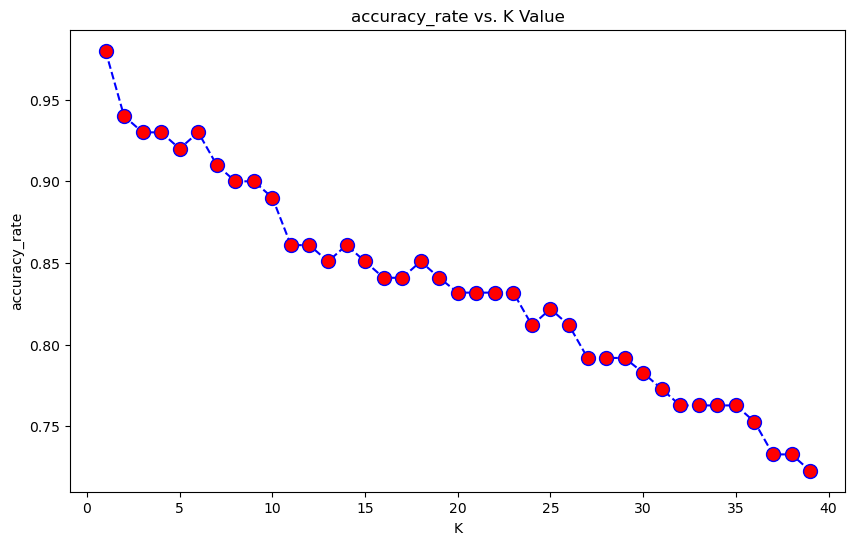

```python
plt.figure(figsize=(10,6))
#plt.plot(range(1,40),accuracy_rate,color='blue', linestyle='dashed', marker='o',
  #       markerfacecolor='red', markersize=10)
plt.plot(range(1,40),accuracy_rate,color='blue', linestyle='dashed', marker='o',
         markerfacecolor='red', markersize=10)
plt.title('accuracy_rate vs. K Value')
plt.xlabel('K')
plt.ylabel('accuracy_rate')
```

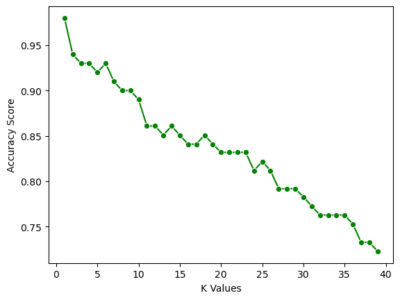

```python
sns.lineplot(x = k_values, y = accuracy_rate, marker = 'o',color = 'green')
plt.xlabel("K Values")
plt.ylabel("Accuracy Score")
```

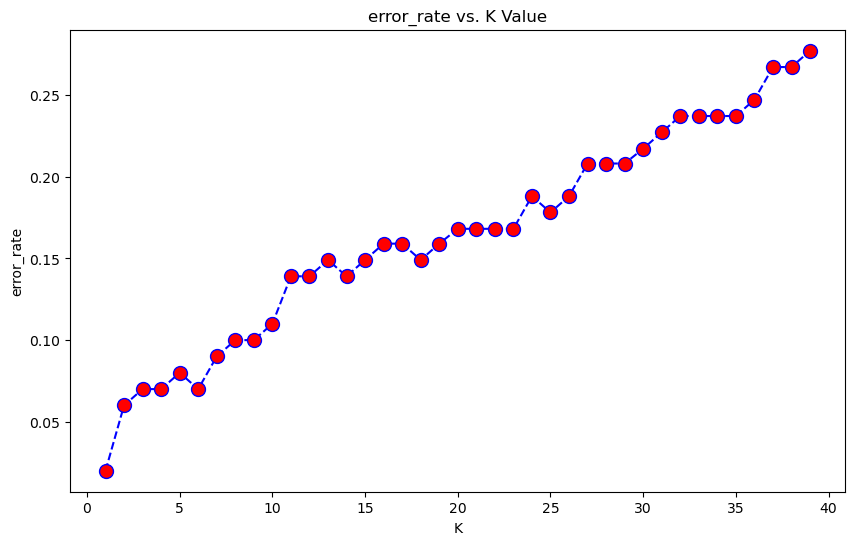

```python
plt.figure(figsize=(10,6))
#plt.plot(range(1,40),error_rate,color='blue', linestyle='dashed', marker='o',
  #       markerfacecolor='red', markersize=10)
plt.plot(range(1,40),error_rate,color='blue', linestyle='dashed', marker='o',
         markerfacecolor='red', markersize=10)
plt.title('error_rate vs. K Value')
plt.xlabel('K')
plt.ylabel('error_rate')
```

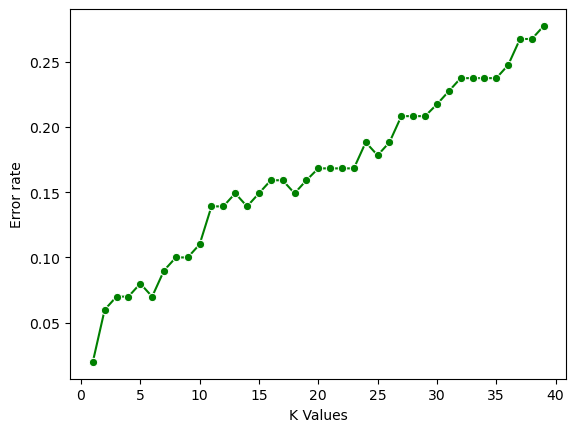

```python
sns.lineplot(x = k_values, y = error_rate, marker = 'o',color = 'green')
plt.xlabel("K Values")
plt.ylabel("Error rate")
```

## Stept3 :- choosing best k value

```python
from sklearn.model_selection import GridSearchCV

# Define the parameter grid
param_grid = {
    'n_neighbors': list(range(1, 40)),
    'metric': ['euclidean', 'manhattan', 'minkowski'],
    #'p': [1, 2]  # Only for Minkowski
}
```

```python
# Perform grid search
grid_search = GridSearchCV(knn, param_grid, cv=5, scoring='accuracy')
grid_search.fit(Scales_features, y)
```

```
GridSearchCV(cv=5, estimator=KNeighborsClassifier(n_neighbors=39),
             param_grid={'metric': ['euclidean', 'manhattan', 'minkowski'],
                         'n_neighbors': [1, 2, 3, 4, 5, 6, 7, 8, 9, 10, 11, 12,
                                         13, 14, 15, 16, 17, 18, 19, 20, 21, 22,
                                         23, 24, 25, 26, 27, 28, 29, 30, ...]},
             scoring='accuracy')
```

```python
# Get the best parameters
best_params = grid_search.best_params_
print("Best parameters:", best_params)
```

```
Best parameters: {'metric': 'euclidean', 'n_neighbors': 1}
```

```python
#for training the best model
#Train the best model
#best_knn = grid_search.best_estimator_
#best_knn.fit(Scales_features, y)
```

```python
# FIRST A QUICK COMPARISON TO OUR ORIGINAL K=1
knn = KNeighborsClassifier(n_neighbors=1)

knn.fit(x_train,y_train)
y_pred = knn.predict(x_test)

print('WITH K=1')
print('\n')
print(confusion_matrix(y_test,y_pred))
print('\n')
print(classification_report(y_test,y_pred))
```

```
WITH K=1


[[7 0 0 0 0 0 0]
 [0 3 0 0 0 0 0]
 [0 0 1 0 0 0 0]
 [0 0 0 4 0 0 0]
 [0 0 0 0 1 0 0]
 [0 0 0 0 0 2 0]
 [0 0 0 0 0 0 2]]


              precision    recall  f1-score   support

           1       1.00      1.00      1.00         7
           2       1.00      1.00      1.00         3
           3       1.00      1.00      1.00         1
           4       1.00      1.00      1.00         4
           5       1.00      1.00      1.00         1
           6       1.00      1.00      1.00         2
           7       1.00      1.00      1.00         2

    accuracy                           1.00        20
   macro avg       1.00      1.00      1.00        20
weighted avg       1.00      1.00      1.00        20
```

### Applying PCA algorithm

```python
from sklearn.decomposition import PCA
```

```python
pca = PCA(n_components=3)
```

```python
pca_data = pca.fit_transform(Scales_features)
```

```python
pca_data
```

```
array([[-2.65134692, -0.23390446,  1.30989029],
       [-2.98329208, -0.38046848, -0.03816587],
       [ 1.62992772,  3.74565307, -0.09372656],
       [-2.64406488, -0.23598619,  1.3048632 ],
       [-2.91946214,  0.12635193,  0.19069873],
       [-2.97358268, -0.38324412, -0.04486865],
       [-3.26901525, -0.73115374, -0.26870813],
       [ 1.28765665,  2.88606567, -0.55816051],
       [ 1.64449182,  3.74148962, -0.10378074],
       [-2.40432269, -1.28055918,  0.98434169],
       [-2.90489804,  0.12218848,  0.18064454],
       [ 1.66519614, -2.22368177, -2.63939847],
       [ 1.65420122,  3.73871398, -0.11048353],
       [ 2.49402191,  0.19193517,  2.19015303],
       [ 2.69348238,  0.30113299,  2.9416589 ],
       [ 2.58235972, -0.03552008,  3.25014395],
       [ 2.03174071, -1.37103346, -2.1917215 ],
       [-2.94445449, -0.39157102, -0.06497702],
       [ 1.08917941,  3.91884222, -0.26612584],
       [-1.19593134,  3.01908787, -0.6414561 ],
       [ 1.68704229, -2.22992694, -2.65447974],
       [ 2.4114627 , -1.1015951 , -2.30113161],
       [-2.93231774, -0.39504056, -0.0733555 ],
       [ 1.41259835, -1.70050127, -2.58293119],
       [ 1.61390735, -2.2387768 ,  2.39314759],
       [ 1.01373056,  0.57193589,  1.24629438],
       [ 1.37606987,  0.57916307,  2.06599392],
       [-1.76969024, -0.97676293, -0.89166862],
       [-2.92018099, -0.39851011, -0.08173399],
       [-2.76769104, -0.26459045,  0.73064625],
       [ 2.08582627, -2.97286054,  1.7377314 ],
       [-3.21075886, -0.74780754, -0.30892486],
       [-2.51909697, -0.42835861,  0.71389125],
       [ 2.49471145, -0.60032595, -2.08567259],
       [ 1.64862767,  3.21523976, -0.37956485],
       [-2.62146355, -0.93487487, -0.17003952],
       [-2.32117628, -0.58835307,  0.05044856],
       [ 2.0802877 , -1.38491163, -2.22523544],
       [ 1.71488496,  3.72136627, -0.15237596],
       [ 1.34939774, -3.55200286,  2.51882878],
```

[output cut: 46 more lines]

```
       [ 1.61415115,  3.87957754,  0.441302  ],
       [ 1.98965453, -0.96240746, -2.55564004],
       [ 1.76683038, -2.28249304,  2.28757867],
       [ 1.1101057 ,  0.01931751,  0.90683378],
       [ 0.49248896, -0.86944046, -0.53056212],
       [ 0.46955054,  0.10805381, -0.10797476],
       [ 1.26637594,  3.8681869 , -0.38845173],
       [-1.60948516, -1.0225609 , -1.00226462],
       [-2.18039   , -0.62859977, -0.04674187],
       [ 1.64148808, -1.24086663, -2.46801399],
       [-2.6415712 , -0.10973673, -0.50584214],
       [ 1.78804395, -3.24503385,  2.64380212],
       [-2.69371861,  0.06181843,  0.0348589 ],
       [ 2.13418126, -1.28224856,  1.33866375],
       [ 2.17666284, -1.93753001, -2.56469604]])
```

```python
pca.explained_variance_
```

```
array([4.73547058, 3.37562723, 2.391318  ])
```

```python
from mpl_toolkits.mplot3d import Axes3D
```

```python
print(zoo.columns)
```

```
Index(['animal name', 'hair', 'feathers', 'eggs', 'milk', 'airborne',
       'aquatic', 'predator', 'toothed', 'backbone', 'breathes', 'venomous',
       'fins', 'legs', 'tail', 'domestic', 'catsize', 'type'],
      dtype='object')
```

### Assuming pca_data is a numpy array with shape (n_samples, n_components) and zoo['type'] is the target column.

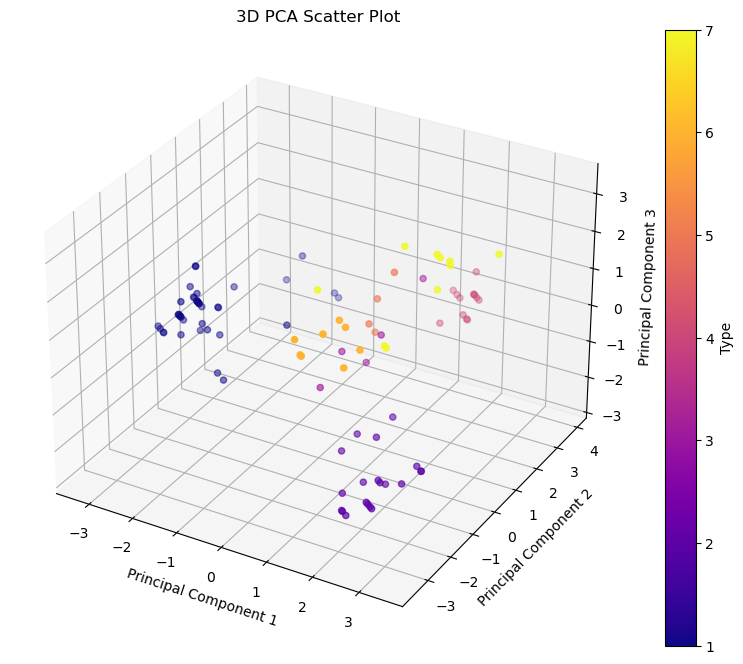

```python
fig = plt.figure(figsize=(10, 8))
ax = fig.add_subplot(111, projection='3d')

# Scatter plot
scatter = ax.scatter(pca_data[:, 0], pca_data[:, 1], pca_data[:, 2], c=zoo['type'], cmap='plasma')

# Add color bar

cbar = plt.colorbar(scatter)
cbar.set_label('Type')

# Labels and title

ax.set_xlabel('Principal Component 1')
ax.set_ylabel('Principal Component 2')
ax.set_zlabel('Principal Component 3')
ax.set_title('3D PCA Scatter Plot')

plt.show()
```

# Interview Questions:

### 1. What are the key hyperparameters in KNN?

The key hyperparameters in K-Nearest Neighbors (KNN) are:

Number of Neighbors (k):

This is the most crucial hyperparameter. It specifies the number of nearest neighbors to consider when making a prediction. A smaller value of 𝑘 k makes the model more sensitive to noise, while a larger value smoothens the decision boundary but may include points from other classes. Distance Metric:

Determines how the distance between points is calculated. Common choices include: Euclidean Distance: The most common distance metric, calculated as the straight-line distance between two points. Manhattan Distance: Sum of the absolute differences between the coordinates of the points. Minkowski Distance: Generalization of Euclidean and Manhattan distances. Hamming Distance: Used for categorical variables. Other domain-specific or custom distances. Weighting Function:

This hyperparameter decides how the contribution of each neighbor is weighted. Common options are: Uniform Weights: All neighbors contribute equally. Distance Weights: Closer neighbors have a greater influence on the prediction than distant ones. Typically, the weight is inversely proportional to the distance. Algorithm:

Specifies the underlying algorithm used for finding nearest neighbors. Choices include: Ball Tree: Efficient for high-dimensional data. KD Tree: Works well for lower-dimensional data. Brute Force: Computes distances directly and works well for small datasets. Leaf Size:

Relevant when using tree-based algorithms (Ball Tree or KD Tree). It affects the speed of the construction and query processes. Smaller leaf sizes lead to more accurate searches but increase the computational cost. P Parameter (for Minkowski Distance):

Defines the power parameter for the Minkowski distance. For p=1, it is equivalent to the Manhattan distance, and for p=2, it is equivalent to the Euclidean distance.

7.n_jobs:

-The number of parallel jobs to run for the search. A value of -1 uses all available processors. Tuning these hyperparameters appropriately is crucial for optimizing the performance of a KNN model, as they directly influence the model's accuracy and computational efficiency.

### 2. What distance metrics can be used in KNN?

1.Euclidean Distance:

-The most widely used distance metric, calculated as the straight-line distance between two points in Euclidean space.

2.Manhattan Distance (L1 Distance):

-Also known as the taxicab or city block distance, it is the sum of the absolute differences of their Cartesian coordinates.

3.Minkowski Distance:

-A generalization of both Euclidean and Manhattan distances, parameterized by a value 𝑝.

4.Hamming Distance:

-Used for categorical data, it measures the number of positions at which the corresponding symbols are different.

-Commonly used in text comparison and for binary attributes.

5.Chebyshev Distance (L∞ Distance):

-Measures the maximum absolute difference along any coordinate dimension.

6.Mahalanobis Distance:

-Takes into account the correlations of the data set and is scale-invariant.

7.Cosine Similarity:

-Measures the cosine of the angle between two non-zero vectors, often used for text or high-dimensional data.

8.Jaccard Distance:

-Used for comparing the similarity and diversity of sample sets.

9.Bray-Curtis Distance:

-Used for measuring the dissimilarity between two data points based on their abundances.

The choice of distance metric depends on the nature of the data and the specific problem at hand. Euclidean distance is often the default choice, but other metrics might be more appropriate for different types of data or applications.

### KNN classifier goes for Majority

### KNN regression goes for average(Mean)